Khofiyya Mulia Rahmi

# Intoduction

Dalam kasus ini, terdapat Data Bunuh Diri di Duni pada Tahun 1985-2015. Di sini saya akan memberikan data visualization Suicide Worldwide Dataset, yang dimana bahwa sesuatu data pasti mempunnyai karakterisitik atau mempunya sebuah informasi maka dari itu saya akan mevisualisasikan data bunuh diri worldwide.

1. Country
2. Year: 1985 to 2016
3. Sex: Male/female
4. Age: Five age groups
5. Generation
6. Population
7. Number of Suicides: Suicide incidences
8. Suicides per 100k people:normalized version of suicide incidences
9. GDP for year: Gross Domestic Product(a measure of economic development)
10. GDP per capita for year: GDP/population
11. HDI for year : Human Development Index

# Import Libraries

```python
import numpy as np
import pandas as pd
import matplotlib.pyplot as plt
import seaborn as sns
plt.style.use('seaborn')
```

```python
import numpy as np # linear algebra
import pandas as pd # data processing, CSV file I/O (e.g. pd.read_csv)

# For data visualization
import matplotlib.pyplot as plt
import matplotlib as mpl
import seaborn as sns; sns.set()

# Disabling warnings
import warnings
warnings.simplefilter("ignore")
```

# Data loading

```python
data_suicide = pd.read_csv('suicide.csv')
```

```python
data_suicide.head()
```

|  | country | year | sex | age | suicides_no | population | suicides/100k pop | country-year | HDI for year | gdp_for_year ($) | gdp_per_capita ($) | generation |
| --- | --- | --- | --- | --- | --- | --- | --- | --- | --- | --- | --- | --- |
| 0 | Albania | 1987 | male | 15-24 years | 21 | 312900 | 6.71 | Albania1987 | NaN | 2,156,624,900 | 796 | Generation X |
| 1 | Albania | 1987 | male | 35-54 years | 16 | 308000 | 5.19 | Albania1987 | NaN | 2,156,624,900 | 796 | Silent |
| 2 | Albania | 1987 | female | 15-24 years | 14 | 289700 | 4.83 | Albania1987 | NaN | 2,156,624,900 | 796 | Generation X |
| 3 | Albania | 1987 | male | 75+ years | 1 | 21800 | 4.59 | Albania1987 | NaN | 2,156,624,900 | 796 | G.I. Generation |
| 4 | Albania | 1987 | male | 25-34 years | 9 | 274300 | 3.28 | Albania1987 | NaN | 2,156,624,900 | 796 | Boomers |

```python
data_suicide.info()
```

```
<class 'pandas.core.frame.DataFrame'>
RangeIndex: 27820 entries, 0 to 27819
Data columns (total 12 columns):
 #   Column              Non-Null Count  Dtype
---  ------              --------------  -----
 0   country             27820 non-null  object
 1   year                27820 non-null  int64
 2   sex                 27820 non-null  object
 3   age                 27820 non-null  object
 4   suicides_no         27820 non-null  int64
 5   population          27820 non-null  int64
 6   suicides/100k pop   27820 non-null  float64
 7   country-year        27820 non-null  object
 8   HDI for year        8364 non-null   float64
 9    gdp_for_year ($)   27820 non-null  object
 10  gdp_per_capita ($)  27820 non-null  int64
 11  generation          27820 non-null  object
dtypes: float64(2), int64(4), object(6)
memory usage: 2.5+ MB
```

```python
data_suicide.isnull().sum()
```

```
country                   0
year                      0
sex                       0
age                       0
suicides_no               0
population                0
suicides/100k pop         0
country-year              0
HDI for year          19456
 gdp_for_year ($)         0
gdp_per_capita ($)        0
generation                0
dtype: int64
```

# Menurut jenis kelamin berdasarkan populasi siapa yang paling banyak?

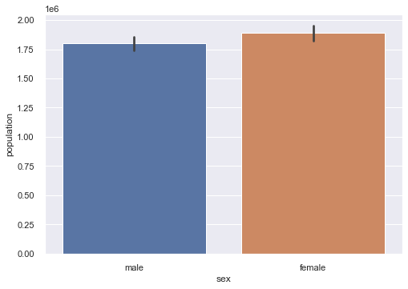

```python
sns.barplot(x="sex", y="population", data=data_suicide)
```

Dari hasil di atas, menggambarkan bahwa berdasarkan jeniskelamin dari populasi terbanyak adalah female perempuan.

# Jenis kelamin apa yang paling banyak melakukan bunuh diri ?

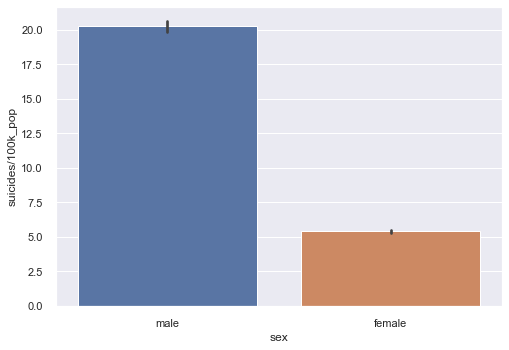

```python
sns.barplot(x="sex", y="suicides/100k_pop", data=data_suicide)
```

Ternyata, kasus bunuh diri terbanyak adalah male, laki-laki.

# Nah, sekarang kita lihat, bagaimana gambaran berdasarkan umur dan gender dalam kasus bunuh diri ini.

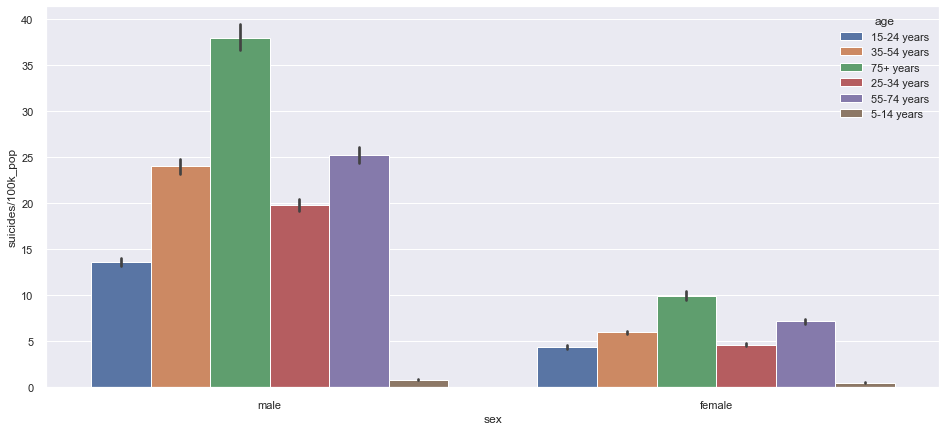

```python
### Set figure size
plt.figure(figsize=(16,7))
###Let's plot the barplot
bar_age = sns.barplot(x = 'sex', y = 'suicides/100k_pop', hue = 'age',data = data_suicide)
```

Dapat dilihat, termyata kasus bunuh diri ini paling tinggi terdapat di umur 75+ tahun, tidak perempuan dan tidak laki-laki sama, sedang terendah diumur 5-14 tahun

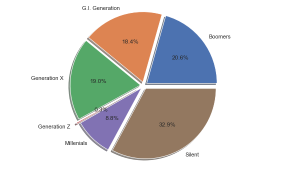

```python
gen_sui = data_suicide.pivot_table('suicides/100k_pop', index='generation', aggfunc='sum')
x = gen_sui.index.values
y = gen_sui.values
y = y.reshape(6,)

fig, ax = plt.subplots(figsize=(10, 6))
explode = (0.05,0.05,0.05,0.1,0.05,0.05)
ax.pie(y, explode=explode, labels=x, autopct='%1.1f%%', shadow=True, startangle=0)
ax.axis('equal')  # Equal aspect ratio ensures that pie is drawn as a circle.
plt.show()
```

seperti di barplot di atas, dari piechart ini juga menggambarkan generasi silent terbanyak yang dimana generasi silient ini berumur 75+ tahun.

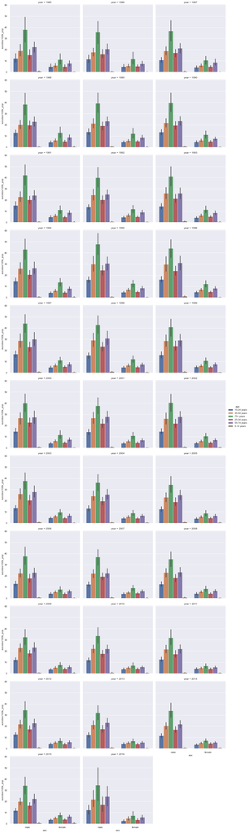

```python
cat_accord_year = sns.catplot('sex','suicides/100k_pop',hue='age',col='year',data=data_suicide,kind='bar',col_wrap=3)
```

Di atas menunjukan memang terbanyak kasus bunuh diri ini adalah laki2 di tahun 1995 yang berumur 75+ tahun

# Selanjutnnya, saya juga mengvisualisasikan ke dalam tableau.

# Tableau Visualization

```python
from IPython.display import IFrame
```

```python
IFrame('https://public.tableau.com/views/SuicideWorldwide1987-2015/Dashboard1?:language=en-US&:display_count=n&:origin=viz_share_link:showVizHome=no&:embed=true', width=900, height=1600)
```

[interactive chart not shown]